# House Price Challenge

This is an assignment for my thinkful data science course. Raj Prasad May 2019

[html version](https://daddyprasad5.github.io/House_Challenge.html) - with all the code hidden away for a quick read

[jupyter notebook version](https://github.com/daddyprasad5/thinkful/blob/master/House_Challenge.ipynb) - with all the code exposed in an interactive notebook

## House prices dataset

I'm demonstrating a linear regression modeling on a house prices dataset originally from Kaggle. This dataset consists of 79 variables describing many aspects of residential homes in Ames, Iowa. Using this data, your task will be to predict the prices of the houses. You can find the descriptions of the variables [here](https://www.kaggle.com/c/house-prices-advanced-regression-techniques/data).

The target variable will be the "SalePrice" (the property's sale price in dollars). Since it's a continuous variable, we're dealing with a regression task.

This overview is presented in 4 parts:

1. Dataset overview and cleaning
2. Feature selection
3. Model fit and evaluation
4. Impact of adding economic metrics as explanatory variables

### Dataset Overview & Cleaning

```python
#imports & connection↔
```

```python
#db connection↔
```

```python
#data load↔
```

```python
#reset index, head of raw data↔
```

|  | id | mssubclass | mszoning | lotfrontage | lotarea | street | alley | lotshape | landcontour | utilities | ... | poolarea | poolqc | fence | miscfeature | miscval | mosold | yrsold | saletype | salecondition | saleprice |
| --- | --- | --- | --- | --- | --- | --- | --- | --- | --- | --- | --- | --- | --- | --- | --- | --- | --- | --- | --- | --- | --- |
| 0 | 1 | 60 | RL | 65.0 | 8450 | Pave | None | Reg | Lvl | AllPub | ... | 0 | None | None | None | 0 | 2 | 2008 | WD | Normal | 208500 |
| 1 | 2 | 20 | RL | 80.0 | 9600 | Pave | None | Reg | Lvl | AllPub | ... | 0 | None | None | None | 0 | 5 | 2007 | WD | Normal | 181500 |
| 2 | 3 | 60 | RL | 68.0 | 11250 | Pave | None | IR1 | Lvl | AllPub | ... | 0 | None | None | None | 0 | 9 | 2008 | WD | Normal | 223500 |
| 3 | 4 | 70 | RL | 60.0 | 9550 | Pave | None | IR1 | Lvl | AllPub | ... | 0 | None | None | None | 0 | 2 | 2006 | WD | Abnorml | 140000 |
| 4 | 5 | 60 | RL | 84.0 | 14260 | Pave | None | IR1 | Lvl | AllPub | ... | 0 | None | None | None | 0 | 12 | 2008 | WD | Normal | 250000 |

5 rows × 81 columns

```python
houses_df.describe()
```

|  | id | mssubclass | lotfrontage | lotarea | overallqual | overallcond | yearbuilt | yearremodadd | masvnrarea | bsmtfinsf1 | ... | wooddecksf | openporchsf | enclosedporch | threessnporch | screenporch | poolarea | miscval | mosold | yrsold | saleprice |
| --- | --- | --- | --- | --- | --- | --- | --- | --- | --- | --- | --- | --- | --- | --- | --- | --- | --- | --- | --- | --- | --- |
| count | 1460.000000 | 1460.000000 | 1201.000000 | 1460.000000 | 1460.000000 | 1460.000000 | 1460.000000 | 1460.000000 | 1452.000000 | 1460.000000 | ... | 1460.000000 | 1460.000000 | 1460.000000 | 1460.000000 | 1460.000000 | 1460.000000 | 1460.000000 | 1460.000000 | 1460.000000 | 1460.000000 |
| mean | 730.500000 | 56.897260 | 70.049958 | 10516.828082 | 6.099315 | 5.575342 | 1971.267808 | 1984.865753 | 103.685262 | 443.639726 | ... | 94.244521 | 46.660274 | 21.954110 | 3.409589 | 15.060959 | 2.758904 | 43.489041 | 6.321918 | 2007.815753 | 180921.195890 |
| std | 421.610009 | 42.300571 | 24.284752 | 9981.264932 | 1.382997 | 1.112799 | 30.202904 | 20.645407 | 181.066207 | 456.098091 | ... | 125.338794 | 66.256028 | 61.119149 | 29.317331 | 55.757415 | 40.177307 | 496.123024 | 2.703626 | 1.328095 | 79442.502883 |
| min | 1.000000 | 20.000000 | 21.000000 | 1300.000000 | 1.000000 | 1.000000 | 1872.000000 | 1950.000000 | 0.000000 | 0.000000 | ... | 0.000000 | 0.000000 | 0.000000 | 0.000000 | 0.000000 | 0.000000 | 0.000000 | 1.000000 | 2006.000000 | 34900.000000 |
| 25% | 365.750000 | 20.000000 | 59.000000 | 7553.500000 | 5.000000 | 5.000000 | 1954.000000 | 1967.000000 | 0.000000 | 0.000000 | ... | 0.000000 | 0.000000 | 0.000000 | 0.000000 | 0.000000 | 0.000000 | 0.000000 | 5.000000 | 2007.000000 | 129975.000000 |
| 50% | 730.500000 | 50.000000 | 69.000000 | 9478.500000 | 6.000000 | 5.000000 | 1973.000000 | 1994.000000 | 0.000000 | 383.500000 | ... | 0.000000 | 25.000000 | 0.000000 | 0.000000 | 0.000000 | 0.000000 | 0.000000 | 6.000000 | 2008.000000 | 163000.000000 |
| 75% | 1095.250000 | 70.000000 | 80.000000 | 11601.500000 | 7.000000 | 6.000000 | 2000.000000 | 2004.000000 | 166.000000 | 712.250000 | ... | 168.000000 | 68.000000 | 0.000000 | 0.000000 | 0.000000 | 0.000000 | 0.000000 | 8.000000 | 2009.000000 | 214000.000000 |
| max | 1460.000000 | 190.000000 | 313.000000 | 215245.000000 | 10.000000 | 9.000000 | 2010.000000 | 2010.000000 | 1600.000000 | 5644.000000 | ... | 857.000000 | 547.000000 | 552.000000 | 508.000000 | 480.000000 | 738.000000 | 15500.000000 | 12.000000 | 2010.000000 | 755000.000000 |

8 rows × 38 columns

```python
houses_df.describe(include="O")
```

|  | mszoning | street | alley | lotshape | landcontour | utilities | lotconfig | landslope | neighborhood | condition1 | ... | garagetype | garagefinish | garagequal | garagecond | paveddrive | poolqc | fence | miscfeature | saletype | salecondition |
| --- | --- | --- | --- | --- | --- | --- | --- | --- | --- | --- | --- | --- | --- | --- | --- | --- | --- | --- | --- | --- | --- |
| count | 1460 | 1460 | 91 | 1460 | 1460 | 1460 | 1460 | 1460 | 1460 | 1460 | ... | 1379 | 1379 | 1379 | 1379 | 1460 | 7 | 281 | 54 | 1460 | 1460 |
| unique | 5 | 2 | 2 | 4 | 4 | 2 | 5 | 3 | 25 | 9 | ... | 6 | 3 | 5 | 5 | 3 | 3 | 4 | 4 | 9 | 6 |
| top | RL | Pave | Grvl | Reg | Lvl | AllPub | Inside | Gtl | NAmes | Norm | ... | Attchd | Unf | TA | TA | Y | Gd | MnPrv | Shed | WD | Normal |
| freq | 1151 | 1454 | 50 | 925 | 1311 | 1459 | 1052 | 1382 | 225 | 1260 | ... | 870 | 605 | 1311 | 1326 | 1340 | 3 | 157 | 49 | 1267 | 1198 |

4 rows × 43 columns

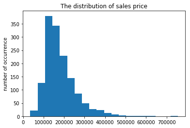

```python
# target variable distribution↔
```

We observe that sales price is not quite normally distributed. Instead, it's highly skewed. **Skewness** is a measure of how asymmetric our data is with respect to the normal distribution. As we see in the graph, the sales price variable is not symmetric but skewed to the right. The majority of the observations have low prices and few of the observations have high prices. This makes the distribution of the charges clustered toward the left.

```python
#look for missing values and drop those columns↔
```

### Feature Selection

```python
#get all the continuous and categorical columns↔
```

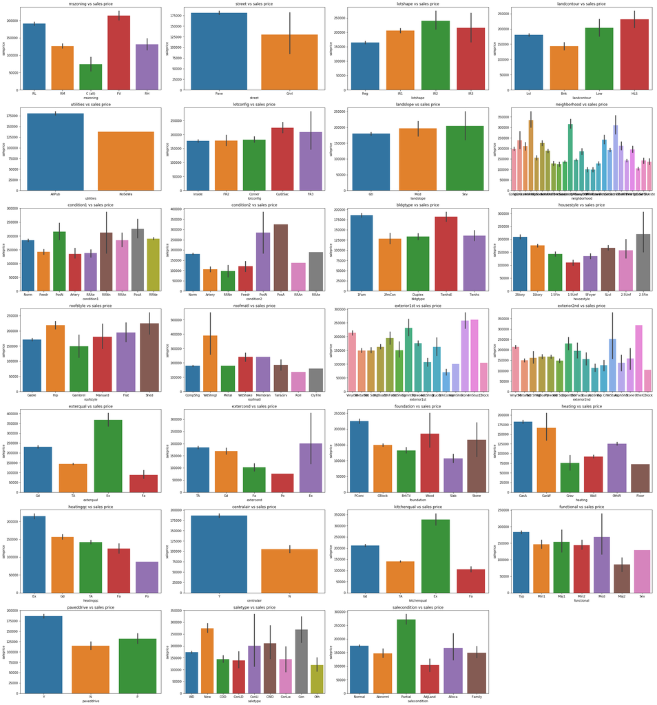

```python
#for catgorical variables - get a visual on which variables split house price↔
```

```python
#transform the promising categorical variables to one-hot columns and create a features dataframe↔
```

```python
#find some powerful continuous variables and list our full feature set↔
```

```
Index(['neighborhood_Blueste', 'neighborhood_BrDale', 'neighborhood_BrkSide',
       'neighborhood_ClearCr', 'neighborhood_CollgCr', 'neighborhood_Crawfor',
       'neighborhood_Edwards', 'neighborhood_Gilbert', 'neighborhood_IDOTRR',
       'neighborhood_MeadowV', 'neighborhood_Mitchel', 'neighborhood_NAmes',
       'neighborhood_NPkVill', 'neighborhood_NWAmes', 'neighborhood_NoRidge',
       'neighborhood_NridgHt', 'neighborhood_OldTown', 'neighborhood_SWISU',
       'neighborhood_Sawyer', 'neighborhood_SawyerW', 'neighborhood_Somerst',
       'neighborhood_StoneBr', 'neighborhood_Timber', 'neighborhood_Veenker',
       'mszoning_FV', 'mszoning_RH', 'mszoning_RL', 'mszoning_RM',
       'exterqual_Fa', 'exterqual_Gd', 'exterqual_TA', 'kitchenqual_Fa',
       'kitchenqual_Gd', 'kitchenqual_TA', 'heatingqc_Fa', 'heatingqc_Gd',
       'heatingqc_Po', 'heatingqc_TA', 'salecondition_AdjLand',
       'salecondition_Alloca', 'salecondition_Family', 'salecondition_Normal',
       'salecondition_Partial', 'overallqual', 'grlivarea', 'garagecars',
       'garagearea', 'totalbsmtsf'],
      dtype='object')
```

## Model Fit and Evaluation

Here's four models, all using all of our chosen features, all trained and evaluated on 80% training & 20% hold out data respectively, and each using a different loss function: LRM, Lasso, Ridge and Elastinet.

The Ridge loss function is slightly better than the others at prediction.

```python
#Model CV implementations, predictions and evaluations for lasso, ridge and elasticnet↔
```

|  | best_alpha | r_squared_train | r_squared_test | mean_abs_err | mean_sq_err | rt_mean_sq_err | mean_abs_perc_err |
| --- | --- | --- | --- | --- | --- | --- | --- |
| lrm | NaN | 0.836776 | 0.812643 | 22907.335622 | 1.257858e+09 | 35466.291184 | 12.792818 |
| lasso_cv | 100.0 | 0.833036 | 0.808366 | 23043.166742 | 1.286573e+09 | 35868.826412 | 12.992106 |
| ridge_cv | 1.0 | 0.836153 | 0.813426 | 22781.683584 | 1.252601e+09 | 35392.101041 | 12.776246 |
| elasticnet_cv | 100.0 | 0.833036 | 0.808366 | 23043.166742 | 1.286573e+09 | 35868.826412 | 12.992106 |

### 4. Impact of adding economic metrics as explanatory variables

There's a downward trend in sales price during this period. There was of course "great recession" that began in mid-2007, which had a dramatic effect on real estate prices nationally. We could capture some of that information with economic indicators. Let's take a look at a few: 30 year mortgate rates, the s&p 500 index adjusted close, and UCM's consumer sentiment index.

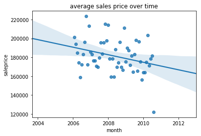

```python
#demonstrate downward trend in saleprice in this period↔
```

```python
#create a dataframe of monthly values for these 3 indicators. ↔
```

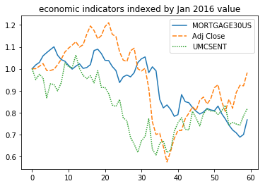

```python
#graph the three indicators↔
```

All of these indicators have a similar downward trend. I could use any of them to attempt to get at the recession malaise.

The first three, one-row tables below each shows the prediction performance of a model that adds one of the three economic metrics. I've used the ridge loss algorithm since that had marginally better predictive power on the base feature set compared to lrm, lasso and elasticnet. The last table is a reprint of the model that has none of these economic metrics.

As you can see, the economic features added little prediction power. I would leave them out of the model for the sake of simplicity.

```python
#build and evaluate 3 new models, each with one of the economic metrics↔
```

|  | best_alpha | r_squared_train | r_squared_test | mean_abs_err | mean_sq_err | rt_mean_sq_err | mean_abs_perc_err |
| --- | --- | --- | --- | --- | --- | --- | --- |
| ridge_mtg | 1.0 | 0.836175 | 0.81365 | 22778.64098 | 1.251101e+09 | 35370.908767 | 12.771385 |

|  | best_alpha | r_squared_train | r_squared_test | mean_abs_err | mean_sq_err | rt_mean_sq_err | mean_abs_perc_err |
| --- | --- | --- | --- | --- | --- | --- | --- |
| ridge_sandp | 1.0 | 0.836159 | 0.81353 | 22779.714933 | 1.251907e+09 | 35382.300135 | 12.775785 |

|  | best_alpha | r_squared_train | r_squared_test | mean_abs_err | mean_sq_err | rt_mean_sq_err | mean_abs_perc_err |
| --- | --- | --- | --- | --- | --- | --- | --- |
| ridge_UMCSENT | 1.0 | 0.836161 | 0.813286 | 22788.770711 | 1.253541e+09 | 35405.38366 | 12.782761 |

|  | best_alpha | r_squared_train | r_squared_test | mean_abs_err | mean_sq_err | rt_mean_sq_err | mean_abs_perc_err |
| --- | --- | --- | --- | --- | --- | --- | --- |
| lrm | NaN | 0.836776 | 0.812643 | 22907.335622 | 1.257858e+09 | 35466.291184 | 12.792818 |
| lasso_cv | 100.0 | 0.833036 | 0.808366 | 23043.166742 | 1.286573e+09 | 35868.826412 | 12.992106 |
| ridge_cv | 1.0 | 0.836153 | 0.813426 | 22781.683584 | 1.252601e+09 | 35392.101041 | 12.776246 |
| elasticnet_cv | 100.0 | 0.833036 | 0.808366 | 23043.166742 | 1.286573e+09 | 35868.826412 | 12.992106 |